# Assignment_7.3

Zach Hill

October 12, 2019

```r
dest <- read.csv('destinations.csv')
test <- read.csv('test.csv')
train <- read.csv('/Temp/train.csv')
```

```r
summary(dest)
str(dest)

head(dest)

# This will be used to show if our predictions from the train dataset are correct
summary(test)
str(test)

head(test)

# Set date_time to POSIX datetime object instead of factor
test$date_time <- anytime(test$date_time)

# This is where we generate our predicted values
summary(train)
str(test)

head(train)

# Set date_time to POSIX datetime object instead of factor
train$date_time <- anytime(train$date_time)

# Take sample of training set to make work bearable.
# We only want bookings because our test dataset only contains bookings
booked <- subset(train, is_booking == 1)
sam <- booked[sample(nrow(booked), 10000),]

str(sam)

# Exporting sample dataset for faster processing later
write.csv(sam, './sample.csv')
```

```r
data <- read.csv('sample.csv')
data$date_time <- anytime(data$date_time)
data$srch_ci <- anytime(data$srch_ci)
data$srch_co <- anytime(data$srch_co)

# Create numeric date values based on date_time
data$date_time <- as.numeric(data$date_time)
data$srch_ci <- as.numeric(data$srch_ci)
data$srch_co <- as.numeric(data$srch_co)

# drop the X column, as imported from excel
data <- subset(data, select = -c(X, cnt, is_booking))

str(data)
```

```
## 'data.frame':    10000 obs. of  22 variables:
##  $ date_time                : num  1.41e+09 1.40e+09 1.38e+09 1.37e+09 1.42e+09 ...
##  $ site_name                : int  13 2 2 11 2 2 24 13 11 37 ...
##  $ posa_continent           : int  1 3 3 3 3 3 2 1 3 1 ...
##  $ user_location_country    : int  46 66 66 205 66 66 3 46 66 69 ...
##  $ user_location_region     : int  347 467 174 135 184 174 50 414 220 1003 ...
##  $ user_location_city       : int  54921 40881 26259 52029 26602 18037 5703 7317 26044 54751 ...
##  $ orig_destination_distance: num  306 831 2388 2131 913 ...
##  $ user_id                  : int  921128 718140 52202 268794 83898 44985 966437 695595 932593 502594 ...
##  $ is_mobile                : int  0 0 0 0 0 1 0 0 0 0 ...
##  $ is_package               : int  1 0 1 1 0 0 0 0 0 1 ...
##  $ channel                  : int  4 9 9 9 9 2 1 9 0 0 ...
##  $ srch_ci                  : num  1.41e+09 1.40e+09 1.38e+09 1.38e+09 1.42e+09 ...
##  $ srch_co                  : num  1.41e+09 1.40e+09 1.38e+09 1.38e+09 1.42e+09 ...
##  $ srch_adults_cnt          : int  2 1 2 2 1 2 2 1 2 2 ...
##  $ srch_children_cnt        : int  0 0 1 0 0 2 0 0 0 0 ...
##  $ srch_rm_cnt              : int  1 1 1 1 1 1 1 1 1 1 ...
##  $ srch_destination_id      : int  8743 16293 8791 8805 18790 8271 1265 597 14127 21676 ...
##  $ srch_destination_type_id : int  1 5 1 1 1 1 1 1 4 6 ...
##  $ hotel_continent          : int  6 2 4 4 2 2 3 6 2 6 ...
##  $ hotel_country            : int  144 50 8 8 50 50 151 21 50 105 ...
##  $ hotel_market             : int  24 406 110 120 361 696 80 14 682 1808 ...
##  $ hotel_cluster            : int  33 59 66 83 28 77 26 85 23 62 ...
```

```r
# Generate list of most commonly selected hotel clusters.
hcf <- plyr::count(data, 'hotel_cluster')
head(hcf[order(-hcf[,2]),], 10)
```

```
##    hotel_cluster freq
## 92            91  407
## 49            48  291
## 60            59  230
## 43            42  227
## 29            28  213
## 83            82  196
## 96            95  189
## 22            21  188
## 17            16  180
## 51            50  175
```

```r
# Create correlation dataframe for analysis
rs <- correlate(data[sapply(data, is.numeric)])
```

```
##
## Correlation method: 'pearson'
## Missing treated using: 'pairwise.complete.obs'
```

```r
View(rs %>% select(rowname,hotel_cluster))

# find any features with over 90 correlation
over_90 <- function(x) any(x > .9, na.rm = TRUE)
rs %>% select_if(over_90)
```

```
## # A tibble: 22 x 4
##    rowname                    date_time   srch_ci   srch_co
##    <chr>                          <dbl>     <dbl>     <dbl>
##  1 date_time                  NA         0.971     0.970
##  2 site_name                  -0.0250    0.00196   0.00247
##  3 posa_continent              0.00925  -0.0125   -0.0134
##  4 user_location_country       0.00309   0.00700   0.00718
##  5 user_location_region       -0.0180   -0.00473  -0.00441
##  6 user_location_city         -0.000436  0.000285  0.000376
##  7 orig_destination_distance  -0.0165    0.0532    0.0548
##  8 user_id                    -0.0174   -0.0119   -0.0119
##  9 is_mobile                   0.00189  -0.00549  -0.00563
## 10 is_package                 -0.0575   -0.0209   -0.0177
## # ... with 12 more rows
```

With dates changed to epoch based numerical values, correlation can be run to find any relatioships. Few, if any were. We may need to come back and reevaluate our features to find better correlations. For now, we’ll investigate what we have.

### Linear Regression

```r
lm_model <- lm(data$hotel_cluster ~ ., data)
lm_pred <- predict(lm_model, data, type = 'response')

lm_model
```

```
##
## Call:
## lm(formula = data$hotel_cluster ~ ., data = data)
##
## Coefficients:
##               (Intercept)                  date_time
##                 6.345e+01                  6.417e-08
##                 site_name             posa_continent
##                 7.332e-02                 -3.343e-02
##     user_location_country       user_location_region
##                -1.495e-02                  2.157e-03
##        user_location_city  orig_destination_distance
##                -3.432e-06                  2.719e-04
##                   user_id                  is_mobile
##                -8.759e-07                 -8.766e-01
##                is_package                    channel
##                 3.932e+00                  1.547e-01
##                   srch_ci                    srch_co
##                -4.631e-06                  4.554e-06
##           srch_adults_cnt          srch_children_cnt
##                 5.853e-01                  6.832e-01
##               srch_rm_cnt        srch_destination_id
##                -1.850e+00                  6.894e-05
##  srch_destination_type_id            hotel_continent
##                -2.739e-01                 -3.850e-02
##             hotel_country               hotel_market
##                -5.537e-03                  1.999e-03
```

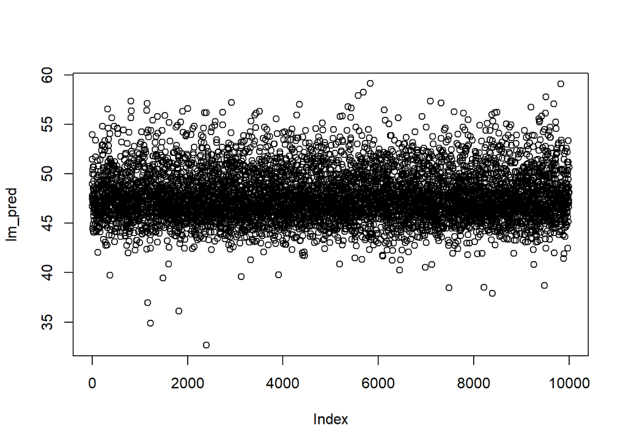

```r
plot(lm_pred)
```

We see nothing linearly correlates with the hotel_clusters. Clearly another method would be better suited.

### Machine Learning

We will run 3-fold cross validation accross the sample, attempting to predict hotel cluster. 4 algorithms will be tested: Random Forest, CART, k-nearest neighbor and a neural network simulation. Hopefully one of these will fit to the nonlinear data.

#### Random Forest

```r
control = trainControl(method = 'cv', number = 3)

rf_model <- train(hotel_cluster ~ ., data, method = 'rf', na.action = na.omit, trControl = control)
rf_pred <- predict(rf_model, data)

rf_model
```

```
## Random Forest
##
## 10000 samples
##    21 predictor
##
## No pre-processing
## Resampling: Cross-Validated (3 fold)
## Summary of sample sizes: 4390, 4390, 4390
## Resampling results across tuning parameters:
##
##   mtry  RMSE      Rsquared     MAE
##    2    29.20310  0.006655804  24.66362
##   11    29.35106  0.006719096  24.78820
##   21    29.36850  0.007035161  24.80133
##
## RMSE was used to select the optimal model using the smallest value.
## The final value used for the model was mtry = 2.
```

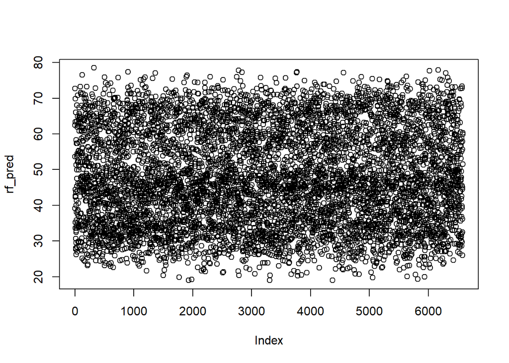

```r
plot(rf_pred)
```

#### CART

```r
cart_model <- train(hotel_cluster ~ ., data, method = 'rpart1SE', na.action = na.pass, trControl = control)
cart_pred <- predict(cart_model, data)

cart_model
```

```
## CART
##
## 10000 samples
##    21 predictor
##
## No pre-processing
## Resampling: Cross-Validated (3 fold)
## Summary of sample sizes: 6667, 6668, 6665
## Resampling results:
##
##   RMSE      Rsquared  MAE
##   29.05839  NaN       24.73091
```

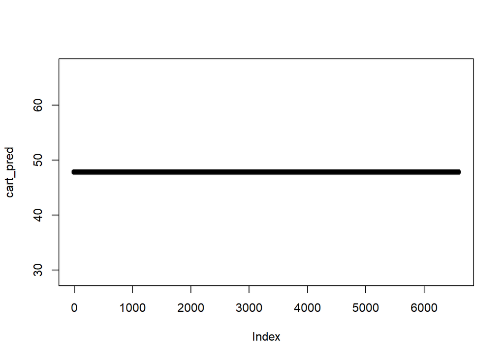

```r
plot(cart_pred)
```

Again we see a high RMSE, and again a less than 50% predictive accuracy even using in-data observations.

#### KNN

```r
knn_control = trainControl(method = 'cv', number = 3, classProbs = FALSE)

knn_model <- train(hotel_cluster ~ ., data, method = 'knn', na.action = na.omit, trControl = control)
knn_pred <- predict(knn_model, data)

knn_model
```

```
## k-Nearest Neighbors
##
## 10000 samples
##    21 predictor
##
## No pre-processing
## Resampling: Cross-Validated (3 fold)
## Summary of sample sizes: 4391, 4389, 4390
## Resampling results across tuning parameters:
##
##   k  RMSE      Rsquared      MAE
##   5  32.05072  0.0009612581  26.67797
##   7  31.27212  0.0006109962  26.19471
##   9  30.82511  0.0004839770  25.89745
##
## RMSE was used to select the optimal model using the smallest value.
## The final value used for the model was k = 9.
```

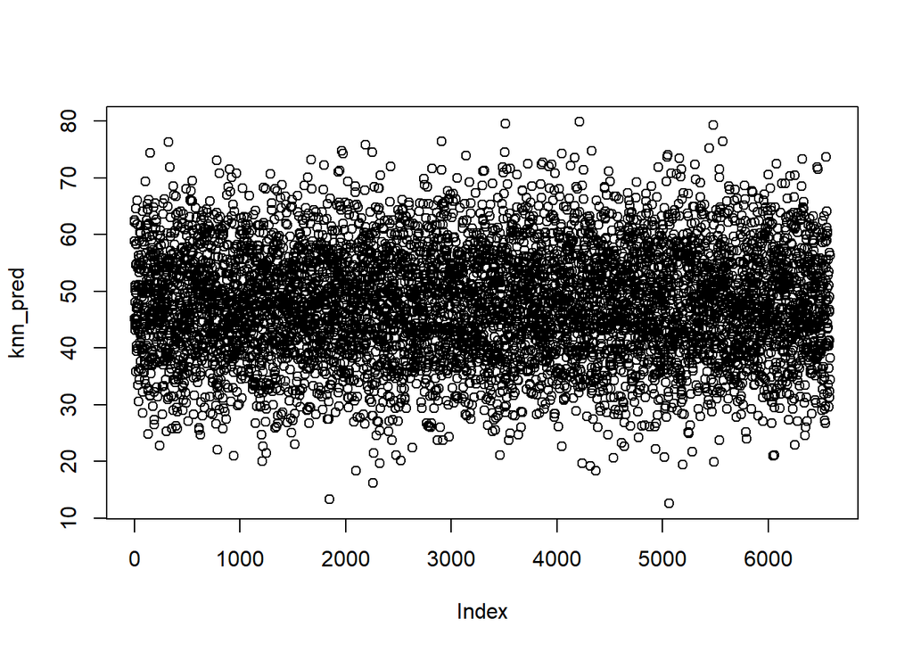

```r
plot(knn_pred)
```

#### Neural Network

```r
nn_control = trainControl(method = 'cv', number = 3, classProbs = FALSE)

nn_model <- train(hotel_cluster ~ ., data, method = 'neuralnet', na.action = na.omit, trControl = control)
nn_pred <- predict(nn_model, data)

nn_model
```

```
## Neural Network
##
## 10000 samples
##    21 predictor
##
## No pre-processing
## Resampling: Cross-Validated (3 fold)
## Summary of sample sizes: 4391, 4390, 4389
## Resampling results across tuning parameters:
##
##   layer1  RMSE     Rsquared  MAE
##   1       29.2059  NaN       24.70377
##   3       29.2059  NaN       24.70377
##   5       29.2059  NaN       24.70377
##
## Tuning parameter 'layer2' was held constant at a value of 0
##
## Tuning parameter 'layer3' was held constant at a value of 0
## RMSE was used to select the optimal model using the smallest value.
## The final values used for the model were layer1 = 3, layer2 = 0 and
##  layer3 = 0.
```

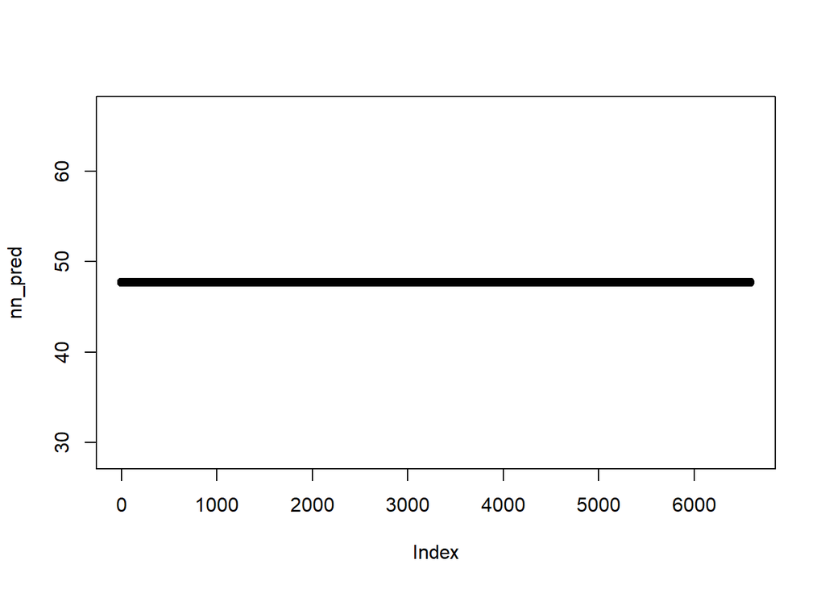

```r
plot(nn_pred)
```

The neural network simulations produced much the same as the other machine learning algorithms.

### Review

Linear regression showed zero success and the machine learning algorithms werent much better. This could be due to the dataset’s features. So far we have only investigated a subset of the training dataset, increasing the number of observations might help but so too might inclusion of the destinations dataset. We may also wish to break down certain features from the training set such as date. Currently it shows raw dates but other factors such as duration of bookings, days of the week for the start and finish of the booking, and month might be relevant and worth investigating.